# Data cleaning AT_ATLIBERIA

AT_ATLIBERIA

Alicia Valdés

12 marzo 2025

This script uses several pre-processing methods (SOM + RSI) to improve the quality of training samples for machine learning classification of satellite images.

Documentation: https://e-sensing.github.io/sitsbook/improving-the-quality-of-training-samples.html

# Load libraries

```r
library(dplyr)
library(tibble)
library(purrr)
library(tidyr)
library(sf)
library(sits)
library(kohonen)
library(here)
library(tidyverse)
library(glue)
library(gridExtra)
```

# Load previously saved objects

When running the algorithms, I saved all results that took a long time to generate as R objects in a dedicated folder in my working directory. The code below reads all the objects in this folder.

Below, the code chunks for each of the algorithms that generated these results is set with eval=FALSE to avoid running the algorithms again.

```r
# List all RDS files in the folder
rds_files <- list.files(path = here("r_objects", "AT_ATLIBERIA"),
                        pattern = "\\.rds$", full.names = TRUE)

# Load all RDS files into a list
loaded_objects <- lapply(rds_files, readRDS)

# Name the list elements with the file names (without the .rds extension)
names(loaded_objects) <- basename(rds_files) %>% tools::file_path_sans_ext()

# Assign each object to a variable in the global environment
list2env(loaded_objects, envir = .GlobalEnv)
```

```
<environment: R_GlobalEnv>
```

```r
rm(rds_files)
rm(loaded_objects)
```

# Data prep

## Implementing csv to Rstudio format

The code below converts the original csv file to the format needed. There is no need to run this again if using the previously saved objects.

```r
# Cargamos el csv en la ruta correspondiente.
samples <- read.csv("C:/Data/PAs/AT_ATLIBERIA_R.csv")

# Organizamos en el formato/estructura el csv para que RStudio acepte el formato.

samples_organized <- samples %>%
  pivot_wider(names_from = "band", values_from = "value") %>%  # Volver a formato ancho
  group_by(longitude, latitude, start_date, end_date, label, cube) %>%
  nest(time_series = c(Index, B02, B03, B04, B08, B09, B10))  # Anidar las bandas

samples_organized <- samples_organized %>%
  mutate(time_series = purrr::map(time_series, ~ .x %>%
                             # Convertir Index a formato Date
                             mutate(Index = as.Date(Index, format = "%Y-%m-%d"))))

# Accedemos a la primera time_series
samples_organized$time_series[[1]]

# Posiblemente en la integración de los datos puede llegar a haber en ocasiones
# errores en el formato de los campos por lo que nos aseguramos de que cada campo tenga su formato.

samples_organized <- samples_organized %>%
  mutate(
    start_date = as.Date(start_date, format = "%Y-%m-%d"),  # Convertir a formato Date
    end_date = as.Date(end_date, format = "%Y-%m-%d"),      # Convertir a formato Date
    label = as.character(label)  # Convertir a character
  )
```

## Reclassification

We cannot have label 14 = 2. Cropland together with labels 15 = 2.1. Arable land and 18 = 2.2. Permanent crops. We must reclassify 15 and 18 to 14.

```r
samples_organized <- samples_organized %>%
  mutate(label = if_else(label == "15" | label == "18", "14", label))
```

## HERE, first see distribution!

```r
samples_organized <- samples_organized %>%
  unnest(time_series) %>%
  mutate(sum_B09 = sum(B09)) %>%
  filter(label != 73 | sum_B09 < 0.1) %>% # Keep all labels except 73
  # and for label 73, keep those with sum_B09 < 0.1
  nest(time_series = c(Index, B02, B03, B04, B08, B09, B10)) %>%
  select(-sum_B09)
saveRDS(samples_organized,
        file = here("r_objects", "AT_ALPENNINNE", "samples_organized.rds"))
```

## Ungroup the samples

We need ungroup() for some algorithms to work.

```r
samples_organized_ungr <- samples_organized %>% ungroup()
```

## Transform to sits class

```r
# Se implementa como un conjunto de datos en formato 'group_dbf' y
# para aplicar los procesamientos que queremos tenemos que transformarlo a 'sits'.
class(samples_organized) <- c("sits", class(samples_organized))
class(samples_organized_ungr) <- c("sits", class(samples_organized_ungr))
```

# Obtaining samples using Rstudio (do not use)

No need to run the code below, this is just the code used to obtain the samples using Rstudio that we got from COTESA.

```r
#####________________ COMANDO PARA REALIZAR LA OBTENCIÓN DE LOS SAMPLES MEDIANTE RSTUDIO ________________#####
#####________ SIMPLEMENTE AGREGADO PARA CONOCER COMO SE HA OBTENIDO EL ARCHIVO DATA (NO USADO) __________#####

# Cargamos el datacube en el formato que admite SITS.

datacube <- sits_cube(
  source = "MPC",
  collection = "SENTINEL-2-L2A",
  data_dir = "RUTA/AL/DATACUBE"
)

# Cargamos el shapefile de los puntos que solo deben contener la etiqueta 'label'.

shp_file <- "RUTA/AL/SHAPEFILE.shp"
if (file.exists(shp_file)) {
  sf_shape <- st_read(shp_file)
  print(sf_shape)
} else {
  stop("El archivo no existe en la ruta especificada.")
}
# Obtenemos el samples con el que podemos empezar a realizar los analisis.

samples <- sits_get_data(
  cube         = datacube,
  samples      = sf_shape,
  start_date = "2021-01-01",
  end_date = "2021-12-31",
  progress = TRUE
)
```

# Summary of samples

```r
summary(samples_organized)
```

| label | count | prop |
| --- | --- | --- |
| 1 | 11923 | 0.0243649242 |
| 14 | 17568 | 0.0359006112 |
| 27 | 153596 | 0.3138769513 |
| 30 | 12117 | 0.0247613676 |
| 40 | 19932 | 0.0407314995 |
| 41 | 166360 | 0.3399604783 |
| 47 | 214 | 0.0004373139 |
| 48 | 4402 | 0.0089955880 |
| 49 | 15644 | 0.0319688731 |
| 51 | 66437 | 0.1357655344 |

[output cut: 4 more lines]

Label 14 = previous label 14 + previous label 15 + previous label 18

# Get labels, band, head and class of the samples

```r
sits_labels(samples_organized)
```

```
 [1] "1"  "14" "27" "30" "40" "41" "47" "48" "49" "51" "52" "55" "63" "73"
```

```r
sits_bands(samples_organized)
```

```
[1] "B02" "B03" "B04" "B08" "B09" "B10"
```

```r
head(samples_organized)
```

| longitude | latitude | start_date | end_date | label | cube | time_series |
| --- | --- | --- | --- | --- | --- | --- |
| 367475.8 | 4696678 | 2021-01-01 | 2021-12-01 | 41 | SENTINEL-2-L2A |  |
| 367476.3 | 4696681 | 2021-01-01 | 2021-12-01 | 41 | SENTINEL-2-L2A |  |
| 367476.9 | 4696683 | 2021-01-01 | 2021-12-01 | 41 | SENTINEL-2-L2A |  |
| 367478.3 | 4696678 | 2021-01-01 | 2021-12-01 | 41 | SENTINEL-2-L2A |  |
| 367478.8 | 4696680 | 2021-01-01 | 2021-12-01 | 41 | SENTINEL-2-L2A |  |
| 367479.3 | 4696683 | 2021-01-01 | 2021-12-01 | 41 | SENTINEL-2-L2A |  |

```r
class(samples_organized)
```

```
[1] "sits"       "grouped_df" "tbl_df"     "tbl"        "data.frame"
```

# Self-organized map (SOM)

## Creating the SOM map

Clustering technique based on self-organizing maps (SOM). It is a dimensionality reduction technique where high-dimensional data is mapped into a two-dimensional map, keeping the topological relations between data patterns. The SOM 2D map is composed of “neurons”. Each neuron has a weight vector, with the same dimension as the training samples. At the start, neurons are assigned a small random value and then trained by competitive learning. The algorithm computes the distances of each member of the training set to all neurons and finds the neuron closest to the input, called the best matching unit.

(https://e-sensing.github.io/sitsbook/improving-the-quality-of-training-samples.html)

We use a grid size of 25 x 25 (we tested also with 15 x 15 but we saw that 25 x 25 was more conservative, keeping more classes). We keep alpha (starting learning rate) = 1.0, distance =“dtw” and rlen (number of iterations) = 20.

```r
start_time <- Sys.time()
samples_SOM_cluster_25 <- sits_som_map(samples_organized_ungr,
                                    grid_xdim = 25,
                                    grid_ydim = 25,
                                    alpha = 1.0,
                                    distance = "dtw",
                                    rlen = 20)
end_time <- Sys.time()
# Calculate the time difference in hours
time_samples_SOM_cluster_25 <- difftime(end_time, start_time, units = "hours")
print(time_samples_SOM_cluster_25)
# Warnings
saveRDS(samples_SOM_cluster_25,
        file = here("r_objects", "AT_ATLIBERIA", "samples_SOM_cluster_25.rds"))
```

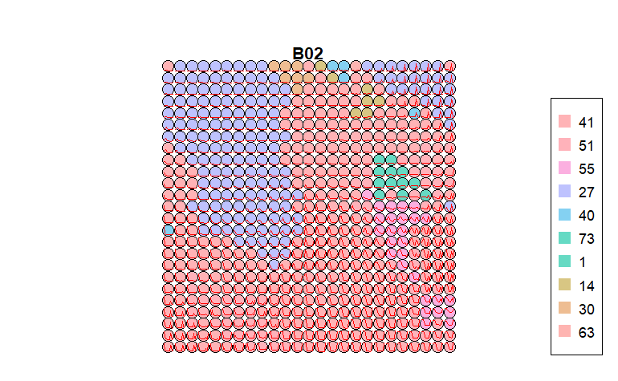

```r
plot(samples_SOM_cluster_25)
```

## Measuring confusion between labels using SOM

The function sits_som_evaluate_cluster() groups neurons by their majority label and produces a tibble. Neurons are grouped into clusters, and there will be as many clusters as there are labels. The results shows the percentage of samples of each label in each cluster. Ideally, all samples of each cluster would have the same label. In practice, clusters contain samples with different labels. This information helps on measuring the confusion between samples.

```r
som_eval_25 <- sits_som_evaluate_cluster(samples_SOM_cluster_25)
```

Plot confusion between clusters.

```r
som_eval_25
```

| id_cluster | cluster | class | mixture_percentage |
| --- | --- | --- | --- |
| 1 | 1 | 1 | 50.326909842 |
| 1 | 1 | 14 | 3.079834825 |
| 1 | 1 | 27 | 1.221610461 |
| 1 | 1 | 30 | 0.980729525 |
| 1 | 1 | 40 | 1.514108741 |
| 1 | 1 | 41 | 9.686854783 |
| 1 | 1 | 48 | 0.309704061 |
| 1 | 1 | 49 | 1.118375774 |
| 1 | 1 | 51 | 21.541637990 |
| 1 | 1 | 52 | 0.086028906 |

[output cut: 105 more lines]

```
Aviso: missing colors for labels1, 14, 27, 30, 40, 41, 48, 49, 51, 52, 55, 73, 47, 63Aviso: palette for missing colors isSet3
```

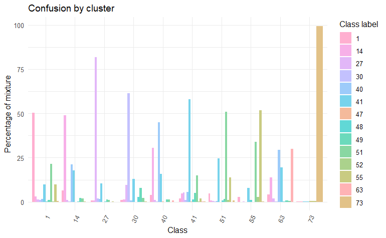

```r
plot(som_eval_25)
```

## Detecting noisy samples using SOM

This approach uses the discrete probability distribution associated with each neuron, which is included in the labeled_neurons tibble produced by sits_som_map(). This approach associates probabilities with frequency of occurrence. More homogeneous neurons (those with one label has high frequency) are assumed to be composed of good quality samples. Heterogeneous neurons (those with two or more classes with significant frequencies) are likely to contain noisy samples.

The function sits_som_clean_samples() finds out which samples are noisy, which are clean, and which need to be further examined by the user.

If the prior probability of a sample is less than prior_threshold, the sample is assumed to be noisy and tagged as “remove”.

If the prior probability is greater or equal to prior_threshold and the posterior probability calculated by Bayesian inference is greater or equal to posterior_threshold, the sample is assumed not to be noisy and thus is tagged as “clean”.

If the prior probability is greater or equal to prior_threshold and the posterior probability is less than posterior_threshold, we have a situation when the sample is part of the majority level of those assigned to its neuron, but its label is not consistent with most of its neighbors. This is an anomalous condition and is tagged as “analyze”. Users are encouraged to inspect such samples to find out whether they are in fact noisy or not.

The default value for both prior_threshold and posterior_threshold is 60%. We have tried with different probabilities for each (0.2 - 0.4 - 0.6 -0.8), using all their possible combinations. We finally decided to keep both probabilities at 0.2 to be more conservative. Higher values of prior_treshold remove more labels, and values of prior_threshold larger than 0.2 always removed at least one of the level 1 labels. The value of posterior_threshold does not affect the labels that are removed, but instead the labels that are tagged as “analyze” (higher values of posterior_threshold tag more labels as “analyze”).

The sits_som_clean_samples() has an additional parameter (keep), which indicates which samples should be kept in the set based on their prior and posterior probabilities. The default for keep is c(“clean”, “analyze”).

Further analysis includes calculating the SOM map and confusion matrix for the new set.

```r
samples_SOM_25_02_02 <- sits_som_clean_samples(samples_SOM_cluster_25,
                                               prior_threshold = 0.2,
                                               posterior_threshold = 0.2,
                                               keep = c("clean", "analyze"))
```

```r
summary(samples_SOM_25_02_02)
```

| label | count | prop |
| --- | --- | --- |
| 1 | 3797 | 0.0099805751 |
| 14 | 6484 | 0.0170434682 |
| 27 | 144574 | 0.3800188729 |
| 30 | 7921 | 0.0208206835 |
| 40 | 5351 | 0.0140653298 |
| 41 | 148082 | 0.3892397993 |
| 49 | 1508 | 0.0039638418 |
| 51 | 49714 | 0.1306753514 |
| 55 | 10920 | 0.0287036818 |
| 63 | 254 | 0.0006676497 |

[output cut: 1 more lines]

```r
summary(samples_SOM_25_02_04)
```

| label | count | prop |
| --- | --- | --- |
| 1 | 3797 | 0.0099805751 |
| 14 | 6484 | 0.0170434682 |
| 27 | 144574 | 0.3800188729 |
| 30 | 7921 | 0.0208206835 |
| 40 | 5351 | 0.0140653298 |
| 41 | 148082 | 0.3892397993 |
| 49 | 1508 | 0.0039638418 |
| 51 | 49714 | 0.1306753514 |
| 55 | 10920 | 0.0287036818 |
| 63 | 254 | 0.0006676497 |

[output cut: 1 more lines]

```r
summary(samples_SOM_25_02_06)
```

| label | count | prop |
| --- | --- | --- |
| 1 | 3797 | 0.0099805751 |
| 14 | 6484 | 0.0170434682 |
| 27 | 144574 | 0.3800188729 |
| 30 | 7921 | 0.0208206835 |
| 40 | 5351 | 0.0140653298 |
| 41 | 148082 | 0.3892397993 |
| 49 | 1508 | 0.0039638418 |
| 51 | 49714 | 0.1306753514 |
| 55 | 10920 | 0.0287036818 |
| 63 | 254 | 0.0006676497 |

[output cut: 1 more lines]

```r
summary(samples_SOM_25_02_08)
```

| label | count | prop |
| --- | --- | --- |
| 1 | 3797 | 0.0099805751 |
| 14 | 6484 | 0.0170434682 |
| 27 | 144574 | 0.3800188729 |
| 30 | 7921 | 0.0208206835 |
| 40 | 5351 | 0.0140653298 |
| 41 | 148082 | 0.3892397993 |
| 49 | 1508 | 0.0039638418 |
| 51 | 49714 | 0.1306753514 |
| 55 | 10920 | 0.0287036818 |
| 63 | 254 | 0.0006676497 |

[output cut: 1 more lines]

```r
summary(samples_SOM_25_04_02)
```

| label | count | prop |
| --- | --- | --- |
| 1 | 2664 | 0.008499587 |
| 14 | 2249 | 0.007175515 |
| 27 | 139316 | 0.444492657 |
| 30 | 5704 | 0.018198815 |
| 40 | 2354 | 0.007510521 |
| 41 | 124958 | 0.398682947 |
| 51 | 26655 | 0.085043726 |
| 55 | 7693 | 0.024544790 |
| 73 | 1834 | 0.005851442 |

```r
summary(samples_SOM_25_04_04)
```

| label | count | prop |
| --- | --- | --- |
| 1 | 2664 | 0.008499587 |
| 14 | 2249 | 0.007175515 |
| 27 | 139316 | 0.444492657 |
| 30 | 5704 | 0.018198815 |
| 40 | 2354 | 0.007510521 |
| 41 | 124958 | 0.398682947 |
| 51 | 26655 | 0.085043726 |
| 55 | 7693 | 0.024544790 |
| 73 | 1834 | 0.005851442 |

```r
summary(samples_SOM_25_04_06)
```

| label | count | prop |
| --- | --- | --- |
| 1 | 2664 | 0.008499587 |
| 14 | 2249 | 0.007175515 |
| 27 | 139316 | 0.444492657 |
| 30 | 5704 | 0.018198815 |
| 40 | 2354 | 0.007510521 |
| 41 | 124958 | 0.398682947 |
| 51 | 26655 | 0.085043726 |
| 55 | 7693 | 0.024544790 |
| 73 | 1834 | 0.005851442 |

```r
summary(samples_SOM_25_04_08)
```

| label | count | prop |
| --- | --- | --- |
| 1 | 2664 | 0.008499587 |
| 14 | 2249 | 0.007175515 |
| 27 | 139316 | 0.444492657 |
| 30 | 5704 | 0.018198815 |
| 40 | 2354 | 0.007510521 |
| 41 | 124958 | 0.398682947 |
| 51 | 26655 | 0.085043726 |
| 55 | 7693 | 0.024544790 |
| 73 | 1834 | 0.005851442 |

```r
summary(samples_SOM_25_06_02)
```

| label | count | prop |
| --- | --- | --- |
| 1 | 819 | 0.003751598 |
| 14 | 538 | 0.002464419 |
| 27 | 132722 | 0.607960349 |
| 30 | 5085 | 0.023292886 |
| 41 | 70427 | 0.322605322 |
| 51 | 5570 | 0.025514528 |
| 55 | 1312 | 0.006009885 |
| 73 | 1834 | 0.008401013 |

```r
summary(samples_SOM_25_06_04)
```

| label | count | prop |
| --- | --- | --- |
| 1 | 819 | 0.003751598 |
| 14 | 538 | 0.002464419 |
| 27 | 132722 | 0.607960349 |
| 30 | 5085 | 0.023292886 |
| 41 | 70427 | 0.322605322 |
| 51 | 5570 | 0.025514528 |
| 55 | 1312 | 0.006009885 |
| 73 | 1834 | 0.008401013 |

```r
summary(samples_SOM_25_06_06)
```

| label | count | prop |
| --- | --- | --- |
| 1 | 819 | 0.003751598 |
| 14 | 538 | 0.002464419 |
| 27 | 132722 | 0.607960349 |
| 30 | 5085 | 0.023292886 |
| 41 | 70427 | 0.322605322 |
| 51 | 5570 | 0.025514528 |
| 55 | 1312 | 0.006009885 |
| 73 | 1834 | 0.008401013 |

```r
summary(samples_SOM_25_06_08)
```

| label | count | prop |
| --- | --- | --- |
| 1 | 819 | 0.003751598 |
| 14 | 538 | 0.002464419 |
| 27 | 132722 | 0.607960349 |
| 30 | 5085 | 0.023292886 |
| 41 | 70427 | 0.322605322 |
| 51 | 5570 | 0.025514528 |
| 55 | 1312 | 0.006009885 |
| 73 | 1834 | 0.008401013 |

```r
summary(samples_SOM_25_08_02)
```

| label | count | prop |
| --- | --- | --- |
| 27 | 102524 | 0.860765020 |
| 41 | 14250 | 0.119639319 |
| 51 | 500 | 0.004197871 |
| 73 | 1834 | 0.015397790 |

```r
summary(samples_SOM_25_08_04)
```

| label | count | prop |
| --- | --- | --- |
| 27 | 102524 | 0.860765020 |
| 41 | 14250 | 0.119639319 |
| 51 | 500 | 0.004197871 |
| 73 | 1834 | 0.015397790 |

```r
summary(samples_SOM_25_08_06)
```

| label | count | prop |
| --- | --- | --- |
| 27 | 102524 | 0.860765020 |
| 41 | 14250 | 0.119639319 |
| 51 | 500 | 0.004197871 |
| 73 | 1834 | 0.015397790 |

```r
summary(samples_SOM_25_08_08)
```

| label | count | prop |
| --- | --- | --- |
| 27 | 102524 | 0.860765020 |
| 41 | 14250 | 0.119639319 |
| 51 | 500 | 0.004197871 |
| 73 | 1834 | 0.015397790 |

## Create the new SOM map

Evaluate the mixture in the SOM clusters of new samples.

```r
start_time <- Sys.time()
samples_SOM_25_02_02_new_cluster <- sits_som_map(samples_SOM_25_02_02,
                                              grid_xdim = 25,
                                              grid_ydim = 25,
                                              alpha = 1.0,
                                              rlen = 20,
                                              distance = "dtw")
end_time <- Sys.time()
# Calculate the time difference in hours
time_samples_SOM_25_02_02_new_cluster <-
  difftime(end_time, start_time, units = "hours")
print(samples_SOM_25_02_02_new_cluster)
saveRDS(samples_SOM_25_02_02_new_cluster,
        file = here("r_objects", "AT_ATLIBERIA",
                    "samples_SOM_25_02_02_new_cluster.rds"))
```

## Measuring confusion between labels using the new SOM map

```r
new_som_eval_25_02_02 <- sits_som_evaluate_cluster(samples_SOM_25_02_02_new_cluster)
new_som_eval_25_02_04 <- sits_som_evaluate_cluster(samples_SOM_25_02_04_new_cluster)
new_som_eval_25_02_06 <- sits_som_evaluate_cluster(samples_SOM_25_02_06_new_cluster)
new_som_eval_25_02_08 <- sits_som_evaluate_cluster(samples_SOM_25_02_08_new_cluster)
new_som_eval_25_04_02 <- sits_som_evaluate_cluster(samples_SOM_25_04_02_new_cluster)
new_som_eval_25_04_04 <- sits_som_evaluate_cluster(samples_SOM_25_04_04_new_cluster)
new_som_eval_25_04_06 <- sits_som_evaluate_cluster(samples_SOM_25_04_06_new_cluster)
new_som_eval_25_04_08 <- sits_som_evaluate_cluster(samples_SOM_25_04_08_new_cluster)
new_som_eval_25_06_02 <- sits_som_evaluate_cluster(samples_SOM_25_06_02_new_cluster)
new_som_eval_25_06_04 <- sits_som_evaluate_cluster(samples_SOM_25_06_04_new_cluster)
new_som_eval_25_06_06 <- sits_som_evaluate_cluster(samples_SOM_25_06_06_new_cluster)
new_som_eval_25_06_08 <- sits_som_evaluate_cluster(samples_SOM_25_06_08_new_cluster)
new_som_eval_25_08_02 <- sits_som_evaluate_cluster(samples_SOM_25_08_02_new_cluster)
new_som_eval_25_08_04 <- sits_som_evaluate_cluster(samples_SOM_25_08_04_new_cluster)
new_som_eval_25_08_06 <- sits_som_evaluate_cluster(samples_SOM_25_08_06_new_cluster)
new_som_eval_25_08_08 <- sits_som_evaluate_cluster(samples_SOM_25_08_08_new_cluster)
```

Plot confusion between clusters.

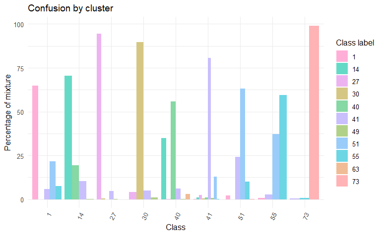

```r
# Plot the confusion between clusters
plot(new_som_eval_25_02_02)
```

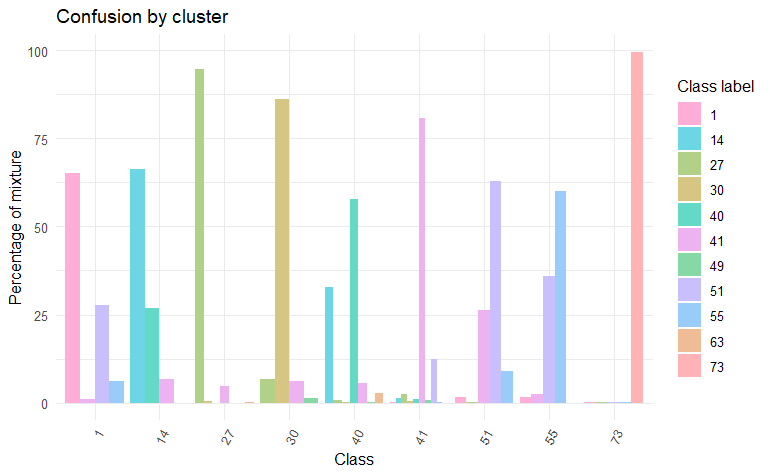

```r
plot(new_som_eval_25_02_04)
```

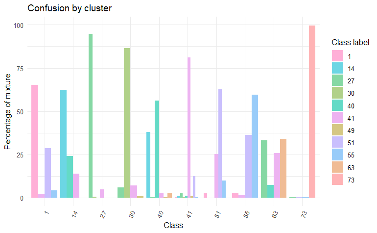

```r
plot(new_som_eval_25_02_06)
```

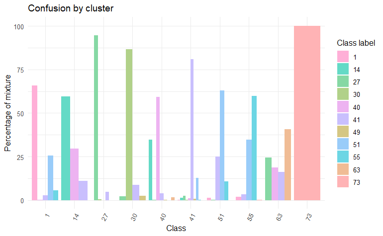

```r
plot(new_som_eval_25_02_08)
```

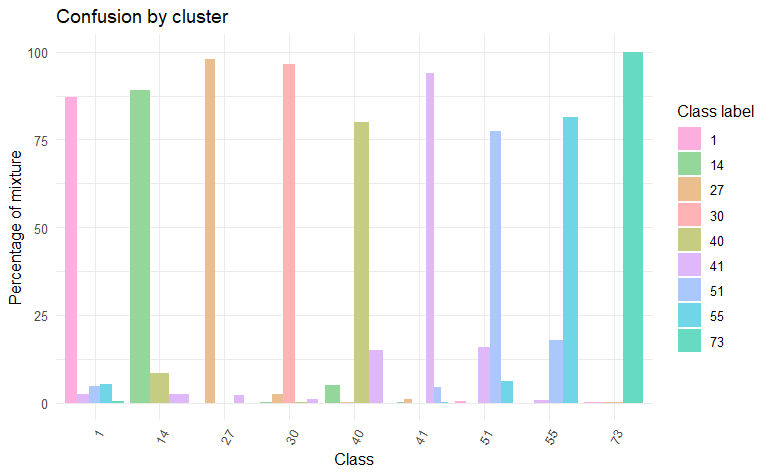

```r
plot(new_som_eval_25_04_02)
```

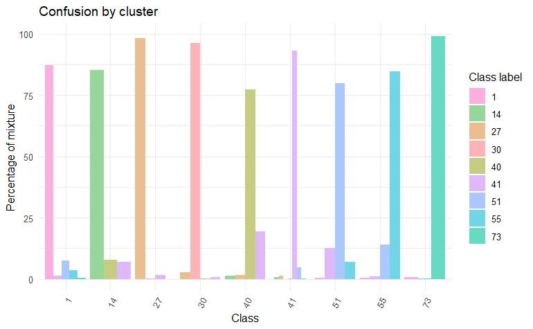

```r
plot(new_som_eval_25_04_04)
```

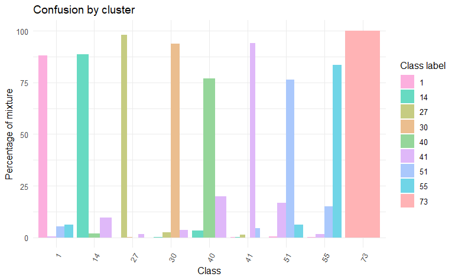

```r
plot(new_som_eval_25_04_06)
```

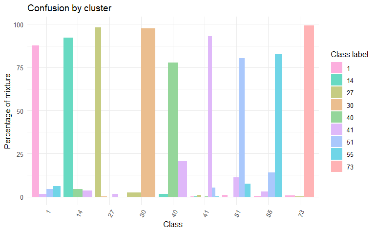

```r
plot(new_som_eval_25_04_08)
```

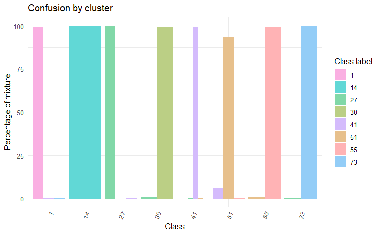

```r
plot(new_som_eval_25_06_02)
```

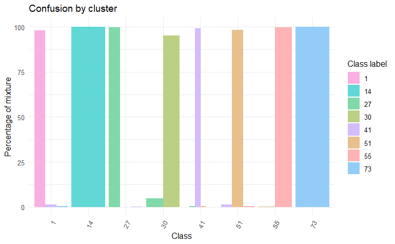

```r
plot(new_som_eval_25_06_04)
```

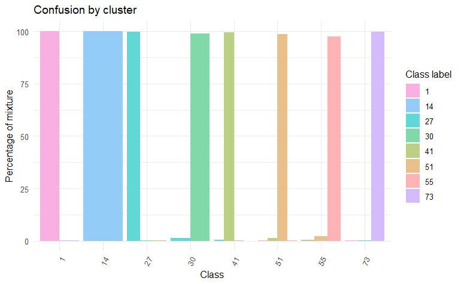

```r
plot(new_som_eval_25_06_06)
```

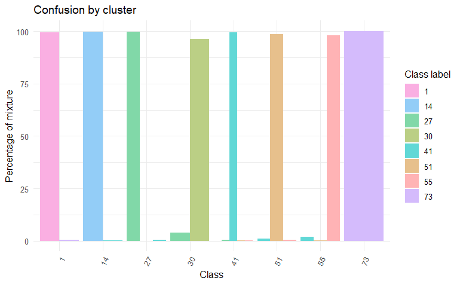

```r
plot(new_som_eval_25_06_08)
```

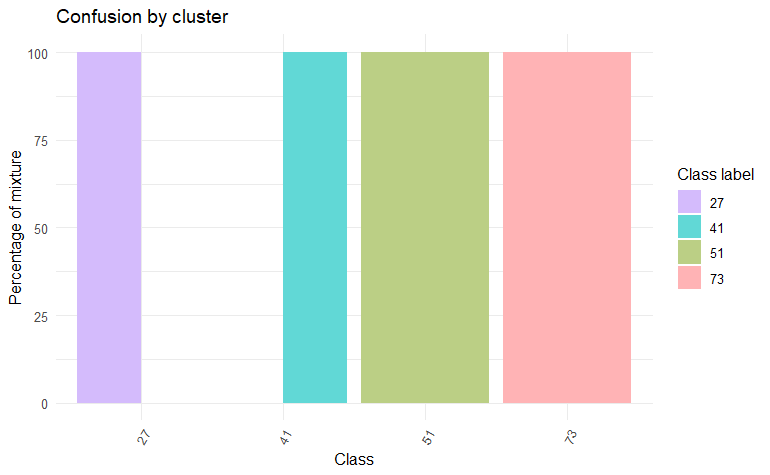

```r
plot(new_som_eval_25_08_02)
```

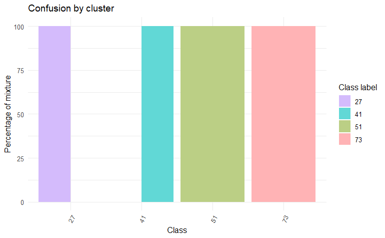

```r
plot(new_som_eval_25_08_04)
```

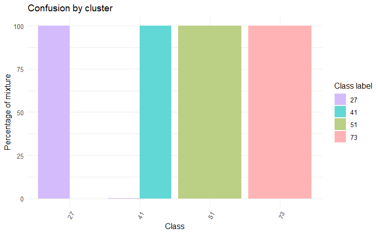

```r
plot(new_som_eval_25_08_06)
```

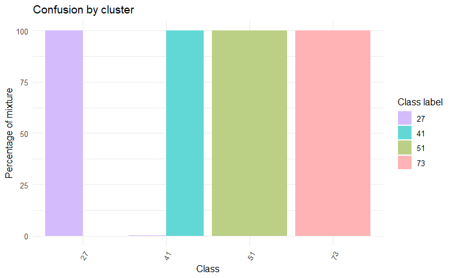

```r
plot(new_som_eval_25_08_08)
```

# Reduce sample imbalance (RSI)

Sample imbalance is an undesirable property of a training set since machine learning algorithms tend to be more accurate for classes with many samples. The instances belonging to the minority group are misclassified more often than those belonging to the majority group. Thus, reducing sample imbalance can positively affect classification accuracy. The function sits_reduce_imbalance() deals with training set imbalance; it increases the number of samples of least frequent labels, and reduces the number of samples of most frequent labels.

We apply the RSI on the samples after applying SOM cleaning.

```r
summary(samples_organized_ungr)
```

| label | count | prop |
| --- | --- | --- |
| 1 | 11923 | 0.0242524714 |
| 14 | 17568 | 0.0357349172 |
| 27 | 153596 | 0.3124282983 |
| 30 | 12117 | 0.0246470851 |
| 40 | 19932 | 0.0405435092 |
| 41 | 166360 | 0.3383914405 |
| 47 | 214 | 0.0004352956 |
| 48 | 4402 | 0.0089540702 |
| 49 | 15644 | 0.0318213254 |
| 51 | 66437 | 0.1351389284 |

[output cut: 4 more lines]

## Apply RSI

RSI needs n_samples_over (minimum number of samples per class) and n_samples_under (maximum number of samples per class). We establish n_samples_over as the count of the class with the minimum number of samples. We establish n_samples_under on the basis of the a priori real probability of the distribution of each of the classes in each bioregion (based on CLC 2018 proportions).

```r
samples_RSI <- sits_reduce_imbalance(
  samples = samples_SOM_25_02_02, # Samples after applying SOM cleaning
  n_samples_over = 214, # Min. number of samples per class
  n_samples_under = 11285, # Max. number of samples per class (based on CLC 2018)
  multicores = 12
)

saveRDS(samples_RSI, file = here("r_objects", "AT_ATLIBERIA", "samples_RSI.rds"))
```

Print the balanced samples.

```r
summary(samples_RSI)
```

[output not shown]

## Creating the SOM map

Clustering time series using SOM.

```r
som_cluster_bal <- sits_som_map(
  data = samples_RSI,
  grid_xdim = 25,
  grid_ydim = 25,
  alpha = 1.0,
  distance = "dtw",
  rlen = 20)

saveRDS(som_cluster_bal, file = here("r_objects", "AT_ATLIBERIA", "som_cluster_bal.rds"))
```

```r
plot(som_cluster_bal)
```

[output not shown]

## Measuring confusion between labels

Estimate the confusion between classes of the balanced dataset.

Produce a tibble with a summary of the mixed labels.

```r
som_eval_RSI <- sits_som_evaluate_cluster(som_cluster_bal)
```

Plot confusion between clusters.

```r
som_eval_RSI
plot(som_eval_RSI)
```

[output not shown]

# Cross-validation

## Original dataset

Estimates the inherent prediction error of a model. Uses only the training samples. It is a measure of model performance on the training data, and not an estimate of overall map accuracy. Uses part of the available samples to fit the classification model and a different part to test it.

```r
# Cross-validation (uncertainties)
# Default: validation_split = 0.2 (proportion of original time series set to be used for validation)
# Default: Machine learning method (sits_rfor())
# There is also sits_kfold_validate
# https://e-sensing.github.io/sitsbook/improving-the-quality-of-training-samples.html#cross-validation-of-training-sets
start_time <- Sys.time()
cross_val <- sits_validate(samples_organized)
end_time <- Sys.time()
# Calculate the time difference in hours
time_cross_val <- difftime(end_time, start_time, units = "hours")
print(time_cross_val)
saveRDS(cross_val, file = here("r_objects", "AT_ATLIBERIA", "cross_val.rds"))

# Shows ca. 80% accuracy
# However, this accuracy does not guarantee a good classification result.
# It only shows if the training data is internally consistent.
# (https://e-sensing.github.io/sitsbook/improving-the-quality-of-training-samples.html)
```

Show the result.

```r
cross_val
```

```
Confusion Matrix and Statistics

          Reference
Prediction     1    14    27    30    40    41    47    48    49    51    52    55    63    73
        1   1260    45    38     8    31    59     0     1     9    88     4    31     0     1
        14    99  2348    31     6   123   106     0     4    10    14     0     0     0     0
        27   143   181 28998   360   383  2233     1    42   283   212     2    33     4     6
        30    13    15   177  1749     8   189     2    53    97    41     0     1     0     0
        40    47    68    16     0  1947    55     0     0     6     3     0     0     0     0
        41   571   818  1366   272  1457 28856    33   343  1865  3700    20   438    12    18
        47     0     0     0     0     0     0     4     0     0     0     0     0     0     0
        48     0     0     7     5     0     5     0   338     0     9     0     3     0     0
        49     3     6    10     8     1    69     1     2   607    38     0     4     0     2
        51   220    33    75    15    36  1661     2    89   251  8998    69  1079     0     6
        52     0     0     0     0     0     0     0     0     0     2   112     2     0     0
        55    29     0     1     0     0    39     0     8     1   181    17  2247     0     0
        63     0     0     0     0     0     0     0     0     0     0     0     0   103     0
        73     0     0     0     0     0     0     0     0     0     1     0     0     0   472

Overall Statistics

               Accuracy : 0.7937
                 95% CI : (0.7911, 0.7962)
    No Information Rate : 0.3384
    P-Value [Acc > NIR] : < 2.2e-16

                  Kappa : 0.7202

 Mcnemar's Test P-Value : NA

Statistics by Class:

                     Class: 1 Class: 14 Class: 27 Class: 30 Class: 40 Class: 41 Class: 47 Class: 48 Class: 49
Sensitivity           0.52830   0.66818    0.9440   0.72183   0.48846    0.8673 9.302e-02  0.384091  0.193992
Specificity           0.99672   0.99585    0.9426   0.99379   0.99793    0.8322 1.000e+00  0.999702  0.998487
Pos Pred Value        0.80000   0.85662    0.8819   0.74584   0.90896    0.7256 1.000e+00  0.920981  0.808256
Neg Pred Value        0.98837   0.98780    0.9737   0.99298   0.97880    0.9246 9.996e-01  0.994467  0.974153
Prevalence            0.02426   0.03574    0.3124   0.02464   0.04054    0.3384 4.373e-04  0.008950  0.031823
Detection Rate        0.01281   0.02388    0.2949   0.01779   0.01980    0.2935 4.068e-05  0.003438  0.006173
Detection Prevalence  0.01602   0.02788    0.3344   0.02385   0.02179    0.4045 4.068e-05  0.003733  0.007638
Balanced Accuracy     0.76251   0.83202    0.9433   0.85781   0.74320    0.8498 5.465e-01  0.691897  0.596240
                     Class: 51 Class: 52 Class: 55 Class: 63 Class: 73
Sensitivity            0.67720  0.500000   0.58546  0.865546  0.934653
Specificity            0.95842  0.999959   0.99708  1.000000  0.999990
Pos Pred Value         0.71789  0.965517   0.89061  1.000000  0.997886
Neg Pred Value         0.95001  0.998860   0.98339  0.999837  0.999663
Prevalence             0.13513  0.002278   0.03903  0.001210  0.005136
Detection Rate         0.09151  0.001139   0.02285  0.001048  0.004800
Detection Prevalence   0.12748  0.001180   0.02566  0.001048  0.004811
Balanced Accuracy      0.81781  0.749980   0.79127  0.932773  0.967322
```

A high accuracy here does not guarantee a good classification result. It only shows if the training data is internally consistent. Cross-validation measures how well the model fits the training data. Using these results to measure classification accuracy is only valid if the training data is a good sample of the entire dataset.

## After SOM

```r
start_time <- Sys.time()
cross_val_SOM <- sits_validate(samples_SOM_25_02_02)
end_time <- Sys.time()
# Calculate the time difference in hours
time_cross_val_SOM <- difftime(end_time, start_time, units = "hours")
print(time_cross_val_SOM)
saveRDS(cross_val_SOM,
        file = here("r_objects", "AT_ATLIBERIA", "cross_val_SOM.rds"))
```

```r
cross_val_samples_SOM_25_02_02_new_cluster
```

```
Confusion Matrix and Statistics

          Reference
Prediction     1    14    27    30    40    41    49    51    55    63    73
        1    623     1     0     0     0    11     0    30     7     0     0
        14     0  1085     0     0    46    22     0     0     0     0     0
        27     0     0 28376    89     1   793     7     4     0     0     0
        30     0     0    44  1431     0    53    12     0     0     0     0
        40     0    54     1     0   830    19     0     0     0     0     0
        41    41   157   494    62   193 27406   226  2215    22     1     0
        49     0     0     0     2     0     7    57     0     0     0     0
        51    82     0     0     0     0  1302     0  7545   448     0     1
        55    13     0     0     0     0     3     0   149  1707     0     0
        63     0     0     0     0     0     0     0     0     0    50     0
        73     0     0     0     0     0     0     0     0     0     0   366

Overall Statistics

               Accuracy : 0.9131
                 95% CI : (0.9111, 0.9151)
    No Information Rate : 0.3892
    P-Value [Acc > NIR] : < 2.2e-16

                  Kappa : 0.8719

 Mcnemar's Test P-Value : NA

Statistics by Class:

                     Class: 1 Class: 14 Class: 27 Class: 30 Class: 40 Class: 41 Class: 49 Class: 51 Class: 55
Sensitivity          0.820817   0.83655    0.9814   0.90341   0.77570    0.9254 0.1887417   0.75883   0.78159
Specificity          0.999350   0.99909    0.9810   0.99854   0.99901    0.9266 0.9998812   0.97229   0.99777
Pos Pred Value       0.927083   0.94102    0.9695   0.92922   0.91814    0.8893 0.8636364   0.80454   0.91186
Neg Pred Value       0.998197   0.99717    0.9885   0.99795   0.99681    0.9512 0.9967772   0.96405   0.99357
Prevalence           0.009975   0.01705    0.3800   0.02082   0.01406    0.3892 0.0039691   0.13068   0.02870
Detection Rate       0.008188   0.01426    0.3729   0.01881   0.01091    0.3602 0.0007491   0.09916   0.02243
Detection Prevalence 0.008832   0.01515    0.3847   0.02024   0.01188    0.4050 0.0008674   0.12325   0.02460
Balanced Accuracy    0.910083   0.91782    0.9812   0.95097   0.88736    0.9260 0.5943115   0.86556   0.88968
                     Class: 63 Class: 73
Sensitivity          0.9803922  0.997275
Specificity          1.0000000  1.000000
Pos Pred Value       1.0000000  1.000000
Neg Pred Value       0.9999868  0.999987
Prevalence           0.0006703  0.004823
Detection Rate       0.0006571  0.004810
Detection Prevalence 0.0006571  0.004810
Balanced Accuracy    0.9901961  0.998638
```

```r
cross_val_samples_SOM_25_04_02_new_cluster
```

```
Confusion Matrix and Statistics

          Reference
Prediction     1    14    27    30    40    41    51    55    73
        1    515     0     0     0     0     1    11     0     0
        14     0   417     0     0     1     2     0     0     0
        27     0     0 27639    23     0   280     0     0     0
        30     0     0    17  1117     0     2     0     0     0
        40     0     4     1     0   444     3     0     0     0
        41     3    29   206     1    26 24285   730     7     0
        51    15     0     0     0     0   417  4508   128     0
        55     0     0     0     0     0     2    82  1404     0
        73     0     0     0     0     0     0     0     0   367

Overall Statistics

               Accuracy : 0.9682
                 95% CI : (0.9668, 0.9696)
    No Information Rate : 0.4445
    P-Value [Acc > NIR] : < 2.2e-16

                  Kappa : 0.9498

 Mcnemar's Test P-Value : NA

Statistics by Class:

                     Class: 1 Class: 14 Class: 27 Class: 30 Class: 40 Class: 41 Class: 51 Class: 55 Class: 73
Sensitivity          0.966229  0.926667    0.9920   0.97897  0.942675    0.9717   0.84562   0.91228  1.000000
Specificity          0.999807  0.999952    0.9913   0.99969  0.999871    0.9734   0.99024   0.99863  1.000000
Pos Pred Value       0.977230  0.992857    0.9892   0.98327  0.982301    0.9604   0.88950   0.94355  1.000000
Neg Pred Value       0.999710  0.999470    0.9936   0.99961  0.999566    0.9811   0.98572   0.99779  1.000000
Prevalence           0.008503  0.007179    0.4445   0.01820  0.007514    0.3987   0.08504   0.02455  0.005854
Detection Rate       0.008215  0.006652    0.4409   0.01782  0.007083    0.3874   0.07191   0.02240  0.005854
Detection Prevalence 0.008407  0.006700    0.4457   0.01812  0.007210    0.4034   0.08085   0.02374  0.005854
Balanced Accuracy    0.983018  0.963309    0.9916   0.98933  0.971273    0.9726   0.91793   0.95545  1.000000
```

```r
cross_val_samples_SOM_25_06_02_new_cluster
```

```
Confusion Matrix and Statistics

          Reference
Prediction     1    14    27    30    41    51    55    73
        1    163     0     0     0     0     0     0     0
        14     0   105     0     0     0     0     0     0
        27     0     0 26480    10    53     0     0     0
        30     0     0     4  1007     0     0     0     0
        41     1     3    58     0 14013    43     1     0
        51     0     0     0     0    19  1068     3     0
        55     0     0     0     0     0     3   258     0
        73     0     0     2     0     0     0     0   367

Overall Statistics

               Accuracy : 0.9954
                 95% CI : (0.9947, 0.996)
    No Information Rate : 0.608
    P-Value [Acc > NIR] : < 2.2e-16

                  Kappa : 0.9913

 Mcnemar's Test P-Value : NA

Statistics by Class:

                     Class: 1 Class: 14 Class: 27 Class: 30 Class: 41 Class: 51 Class: 55 Class: 73
Sensitivity          0.993902  0.972222    0.9976   0.99017    0.9949   0.95871  0.984733  1.000000
Specificity          1.000000  1.000000    0.9963   0.99991    0.9964   0.99948  0.999931  0.999954
Pos Pred Value       1.000000  1.000000    0.9976   0.99604    0.9925   0.97982  0.988506  0.994580
Neg Pred Value       0.999977  0.999931    0.9963   0.99977    0.9976   0.99892  0.999908  1.000000
Prevalence           0.003756  0.002474    0.6080   0.02329    0.3226   0.02551  0.006001  0.008406
Detection Rate       0.003733  0.002405    0.6065   0.02306    0.3210   0.02446  0.005909  0.008406
Detection Prevalence 0.003733  0.002405    0.6079   0.02316    0.3234   0.02497  0.005978  0.008451
Balanced Accuracy    0.996951  0.986111    0.9970   0.99504    0.9957   0.97910  0.992332  0.999977
```

```r
cross_val_samples_SOM_25_08_02_new_cluster
```

```
Confusion Matrix and Statistics

          Reference
Prediction    27    41    51    73
        27 20505     1     0     0
        41     0  2849     0     0
        51     0     0   100     0
        73     0     0     0   367

Overall Statistics

               Accuracy : 1
                 95% CI : (0.9998, 1)
    No Information Rate : 0.8608
    P-Value [Acc > NIR] : < 2.2e-16

                  Kappa : 0.9998

 Mcnemar's Test P-Value : NA

Statistics by Class:

                     Class: 27 Class: 41 Class: 51 Class: 73
Sensitivity             1.0000    0.9996  1.000000   1.00000
Specificity             0.9997    1.0000  1.000000   1.00000
Pos Pred Value          1.0000    1.0000  1.000000   1.00000
Neg Pred Value          1.0000    1.0000  1.000000   1.00000
Prevalence              0.8608    0.1196  0.004198   0.01541
Detection Rate          0.8608    0.1196  0.004198   0.01541
Detection Prevalence    0.8608    0.1196  0.004198   0.01541
Balanced Accuracy       0.9998    0.9998  1.000000   1.00000
```

```r
cross_val_samples_SOM_25_02_04_new_cluster
```

```
Confusion Matrix and Statistics

          Reference
Prediction     1    14    27    30    40    41    49    51    55    63    73
        1    636     3     0     0     0    10     0    34     4     0     0
        14     0  1118     1     1    31    21     0     0     0     0     0
        27     0     0 28381    79     0   756     6     0     0     0     0
        30     0     0    33  1441     0    52    10     0     0     0     0
        40     0    34     0     0   849     9     0     0     0     0     0
        41    35   142   500    63   190 27513   231  2222    22     0     0
        49     0     0     0     0     0     7    55     0     0     0     0
        51    71     0     0     0     0  1241     0  7528   421     0     0
        55    17     0     0     0     0     7     0   159  1737     0     0
        63     0     0     0     0     0     0     0     0     0    51     0
        73     0     0     0     0     0     0     0     0     0     0   367

Overall Statistics

               Accuracy : 0.9157
                 95% CI : (0.9137, 0.9177)
    No Information Rate : 0.3892
    P-Value [Acc > NIR] : < 2.2e-16

                  Kappa : 0.8758

 Mcnemar's Test P-Value : NA

Statistics by Class:

                     Class: 1 Class: 14 Class: 27 Class: 30 Class: 40 Class: 41 Class: 49 Class: 51 Class: 55
Sensitivity          0.837945   0.86199    0.9815   0.90972   0.79346    0.9290 0.1821192   0.75712   0.79533
Specificity          0.999323   0.99928    0.9822   0.99872   0.99943    0.9267 0.9999076   0.97380   0.99752
Pos Pred Value       0.925764   0.95392    0.9712   0.93815   0.95179    0.8899 0.8870968   0.81287   0.90469
Neg Pred Value       0.998369   0.99761    0.9886   0.99808   0.99706    0.9534 0.9967511   0.96386   0.99397
Prevalence           0.009975   0.01705    0.3800   0.02082   0.01406    0.3892 0.0039691   0.13068   0.02870
Detection Rate       0.008359   0.01469    0.3730   0.01894   0.01116    0.3616 0.0007228   0.09894   0.02283
Detection Prevalence 0.009029   0.01540    0.3841   0.02019   0.01172    0.4063 0.0008148   0.12171   0.02523
Balanced Accuracy    0.918634   0.93063    0.9819   0.95422   0.89644    0.9279 0.5910134   0.86546   0.89643
                     Class: 63 Class: 73
Sensitivity          1.0000000  1.000000
Specificity          1.0000000  1.000000
Pos Pred Value       1.0000000  1.000000
Neg Pred Value       1.0000000  1.000000
Prevalence           0.0006703  0.004823
Detection Rate       0.0006703  0.004823
Detection Prevalence 0.0006703  0.004823
Balanced Accuracy    1.0000000  1.000000
```

```r
cross_val_samples_SOM_25_04_04_new_cluster
```

```
Confusion Matrix and Statistics

          Reference
Prediction     1    14    27    30    40    41    51    55    73
        1    509     0     0     0     0     0    12     0     0
        14     0   421     0     0     0     2     0     0     0
        27     0     0 27628    22     0   247     0     0     0
        30     0     0    18  1118     0     0     0     0     0
        40     0     2     3     0   445    10     0     0     0
        41     8    27   214     1    26 24309   749     8     0
        51    15     0     0     0     0   424  4493   132     0
        55     1     0     0     0     0     0    77  1399     0
        73     0     0     0     0     0     0     0     0   367

Overall Statistics

               Accuracy : 0.9681
                 95% CI : (0.9667, 0.9695)
    No Information Rate : 0.4445
    P-Value [Acc > NIR] : < 2.2e-16

                  Kappa : 0.9497

 Mcnemar's Test P-Value : NA

Statistics by Class:

                     Class: 1 Class: 14 Class: 27 Class: 30 Class: 40 Class: 41 Class: 51 Class: 55 Class: 73
Sensitivity          0.954972  0.935556    0.9916   0.97984  0.944798    0.9727   0.84281   0.90903  1.000000
Specificity          0.999807  0.999968    0.9923   0.99971  0.999759    0.9726   0.99004   0.99872  1.000000
Pos Pred Value       0.976967  0.995272    0.9904   0.98415  0.967391    0.9592   0.88724   0.94719  1.000000
Neg Pred Value       0.999614  0.999534    0.9932   0.99963  0.999582    0.9817   0.98546   0.99771  1.000000
Prevalence           0.008503  0.007179    0.4445   0.01820  0.007514    0.3987   0.08504   0.02455  0.005854
Detection Rate       0.008120  0.006716    0.4407   0.01783  0.007099    0.3878   0.07167   0.02232  0.005854
Detection Prevalence 0.008311  0.006748    0.4450   0.01812  0.007338    0.4043   0.08078   0.02356  0.005854
Balanced Accuracy    0.977389  0.967762    0.9919   0.98977  0.972279    0.9726   0.91643   0.95388  1.000000
```

```r
cross_val_samples_SOM_25_06_04_new_cluster
```

```
Confusion Matrix and Statistics

          Reference
Prediction     1    14    27    30    41    51    55    73
        1    164     0     0     0     0     0     0     0
        14     0   106     0     0     0     0     0     0
        27     0     0 26481     7    78     0     0     0
        30     0     0     7  1010     0     0     0     0
        41     0     2    56     0 13984    55     0     0
        51     0     0     0     0    23  1059     4     0
        55     0     0     0     0     0     0   258     0
        73     0     0     0     0     0     0     0   367

Overall Statistics

               Accuracy : 0.9947
                 95% CI : (0.994, 0.9953)
    No Information Rate : 0.608
    P-Value [Acc > NIR] : < 2.2e-16

                  Kappa : 0.9899

 Mcnemar's Test P-Value : NA

Statistics by Class:

                     Class: 1 Class: 14 Class: 27 Class: 30 Class: 41 Class: 51 Class: 55 Class: 73
Sensitivity          1.000000  0.981481    0.9976   0.99312    0.9928   0.95063  0.984733  1.000000
Specificity          1.000000  1.000000    0.9950   0.99984    0.9962   0.99937  1.000000  1.000000
Pos Pred Value       1.000000  1.000000    0.9968   0.99312    0.9920   0.97514  1.000000  1.000000
Neg Pred Value       1.000000  0.999954    0.9963   0.99984    0.9966   0.99871  0.999908  1.000000
Prevalence           0.003756  0.002474    0.6080   0.02329    0.3226   0.02551  0.006001  0.008406
Detection Rate       0.003756  0.002428    0.6065   0.02313    0.3203   0.02426  0.005909  0.008406
Detection Prevalence 0.003756  0.002428    0.6085   0.02329    0.3229   0.02487  0.005909  0.008406
Balanced Accuracy    1.000000  0.990741    0.9963   0.99648    0.9945   0.97500  0.992366  1.000000
```

```r
cross_val_samples_SOM_25_08_04_new_cluster
```

```
Confusion Matrix and Statistics

          Reference
Prediction    27    41    51    73
        27 20505     1     0     0
        41     0  2849     0     0
        51     0     0   100     0
        73     0     0     0   367

Overall Statistics

               Accuracy : 1
                 95% CI : (0.9998, 1)
    No Information Rate : 0.8608
    P-Value [Acc > NIR] : < 2.2e-16

                  Kappa : 0.9998

 Mcnemar's Test P-Value : NA

Statistics by Class:

                     Class: 27 Class: 41 Class: 51 Class: 73
Sensitivity             1.0000    0.9996  1.000000   1.00000
Specificity             0.9997    1.0000  1.000000   1.00000
Pos Pred Value          1.0000    1.0000  1.000000   1.00000
Neg Pred Value          1.0000    1.0000  1.000000   1.00000
Prevalence              0.8608    0.1196  0.004198   0.01541
Detection Rate          0.8608    0.1196  0.004198   0.01541
Detection Prevalence    0.8608    0.1196  0.004198   0.01541
Balanced Accuracy       0.9998    0.9998  1.000000   1.00000
```

```r
cross_val_samples_SOM_25_02_06_new_cluster
```

```
Confusion Matrix and Statistics

          Reference
Prediction     1    14    27    30    40    41    49    51    55    63    73
        1    643     2     0     0     1     6     0    37     2     0     0
        14     0  1095     0     0    54    25     0     0     0     0     0
        27     0     0 28394    79     0   754     6     2     0     0     0
        30     0     0    34  1432     0    58     8     0     0     0     0
        40     0    50     1     0   827    22     0     1     0     3     0
        41    39   150   485    73   188 27447   243  2172    23     1     0
        49     0     0     0     0     0     4    45     0     0     0     0
        51    67     0     1     0     0  1291     0  7591   453     0     0
        55    10     0     0     0     0     9     0   140  1706     0     0
        63     0     0     0     0     0     0     0     0     0    47     0
        73     0     0     0     0     0     0     0     0     0     0   367

Overall Statistics

               Accuracy : 0.9147
                 95% CI : (0.9126, 0.9166)
    No Information Rate : 0.3892
    P-Value [Acc > NIR] : < 2.2e-16

                  Kappa : 0.8742

 Mcnemar's Test P-Value : NA

Statistics by Class:

                     Class: 1 Class: 14 Class: 27 Class: 30 Class: 40 Class: 41 Class: 49 Class: 51 Class: 55
Sensitivity          0.847167   0.84426    0.9820   0.90404   0.77290    0.9268 0.1490066   0.76345   0.78114
Specificity          0.999363   0.99894    0.9822   0.99866   0.99897    0.9274 0.9999472   0.97261   0.99785
Pos Pred Value       0.930535   0.93271    0.9712   0.93473   0.91482    0.8905 0.9183673   0.80730   0.91475
Neg Pred Value       0.998461   0.99730    0.9889   0.99796   0.99677    0.9521 0.9966202   0.96473   0.99356
Prevalence           0.009975   0.01705    0.3800   0.02082   0.01406    0.3892 0.0039691   0.13068   0.02870
Detection Rate       0.008451   0.01439    0.3732   0.01882   0.01087    0.3607 0.0005914   0.09977   0.02242
Detection Prevalence 0.009082   0.01543    0.3842   0.02013   0.01188    0.4051 0.0006440   0.12358   0.02451
Balanced Accuracy    0.923265   0.92160    0.9821   0.95135   0.88594    0.9271 0.5744769   0.86803   0.88949
                     Class: 63 Class: 73
Sensitivity          0.9215686  1.000000
Specificity          1.0000000  1.000000
Pos Pred Value       1.0000000  1.000000
Neg Pred Value       0.9999474  1.000000
Prevalence           0.0006703  0.004823
Detection Rate       0.0006177  0.004823
Detection Prevalence 0.0006177  0.004823
Balanced Accuracy    0.9607843  1.000000
```

```r
cross_val_samples_SOM_25_04_06_new_cluster
```

```
Confusion Matrix and Statistics

          Reference
Prediction     1    14    27    30    40    41    51    55    73
        1    509     0     0     0     0     1     7     0     0
        14     0   418     1     0     2     4     0     0     0
        27     0     0 27666    16     0   280     0     0     0
        30     0     0    11  1124     0     0     0     0     0
        40     0     2     2     0   444     5     0     0     0
        41     7    30   183     1    25 24289   728    10     0
        51    16     0     0     0     0   410  4532   128     0
        55     1     0     0     0     0     3    64  1401     0
        73     0     0     0     0     0     0     0     0   367

Overall Statistics

               Accuracy : 0.9691
                 95% CI : (0.9677, 0.9704)
    No Information Rate : 0.4445
    P-Value [Acc > NIR] : < 2.2e-16

                  Kappa : 0.9512

 Mcnemar's Test P-Value : NA

Statistics by Class:

                     Class: 1 Class: 14 Class: 27 Class: 30 Class: 40 Class: 41 Class: 51 Class: 55 Class: 73
Sensitivity          0.954972  0.928889    0.9929   0.98510  0.942675    0.9719   0.85012   0.91033  1.000000
Specificity          0.999871  0.999888    0.9915   0.99982  0.999855    0.9739   0.99034   0.99889  1.000000
Pos Pred Value       0.984526  0.983529    0.9894   0.99031  0.980132    0.9611   0.89107   0.95371  1.000000
Neg Pred Value       0.999614  0.999486    0.9943   0.99972  0.999566    0.9812   0.98613   0.99775  1.000000
Prevalence           0.008503  0.007179    0.4445   0.01820  0.007514    0.3987   0.08504   0.02455  0.005854
Detection Rate       0.008120  0.006668    0.4413   0.01793  0.007083    0.3875   0.07230   0.02235  0.005854
Detection Prevalence 0.008247  0.006780    0.4461   0.01811  0.007226    0.4032   0.08113   0.02343  0.005854
Balanced Accuracy    0.977422  0.964388    0.9922   0.99246  0.971265    0.9729   0.92023   0.95461  1.000000
```

```r
cross_val_samples_SOM_25_06_06_new_cluster
```

```
Confusion Matrix and Statistics

          Reference
Prediction     1    14    27    30    41    51    55    73
        1    163     0     0     0     0     0     0     0
        14     0   106     0     0     0     0     0     0
        27     0     0 26489     4    51     0     0     0
        30     0     0     4  1013     0     0     0     0
        41     1     2    50     0 14013    35     3     0
        51     0     0     0     0    21  1078     2     0
        55     0     0     0     0     0     1   257     0
        73     0     0     1     0     0     0     0   367

Overall Statistics

               Accuracy : 0.996
                 95% CI : (0.9954, 0.9966)
    No Information Rate : 0.608
    P-Value [Acc > NIR] : < 2.2e-16

                  Kappa : 0.9924

 Mcnemar's Test P-Value : NA

Statistics by Class:

                     Class: 1 Class: 14 Class: 27 Class: 30 Class: 41 Class: 51 Class: 55 Class: 73
Sensitivity          0.993902  0.981481    0.9979   0.99607    0.9949   0.96768  0.980916  1.000000
Specificity          1.000000  1.000000    0.9968   0.99991    0.9969   0.99946  0.999977  0.999977
Pos Pred Value       1.000000  1.000000    0.9979   0.99607    0.9935   0.97911  0.996124  0.997283
Neg Pred Value       0.999977  0.999954    0.9968   0.99991    0.9976   0.99915  0.999885  1.000000
Prevalence           0.003756  0.002474    0.6080   0.02329    0.3226   0.02551  0.006001  0.008406
Detection Rate       0.003733  0.002428    0.6067   0.02320    0.3210   0.02469  0.005886  0.008406
Detection Prevalence 0.003733  0.002428    0.6080   0.02329    0.3230   0.02522  0.005909  0.008429
Balanced Accuracy    0.996951  0.990741    0.9974   0.99799    0.9959   0.98357  0.990446  0.999988
```

```r
cross_val_samples_SOM_25_08_06_new_cluster
```

```
Confusion Matrix and Statistics

          Reference
Prediction    27    41    51    73
        27 20504     4     0     0
        41     1  2845     0     0
        51     0     1   100     0
        73     0     0     0   367

Overall Statistics

               Accuracy : 0.9997
                 95% CI : (0.9995, 0.9999)
    No Information Rate : 0.8608
    P-Value [Acc > NIR] : < 2.2e-16

                  Kappa : 0.999

 Mcnemar's Test P-Value : NA

Statistics by Class:

                     Class: 27 Class: 41 Class: 51 Class: 73
Sensitivity             1.0000    0.9982  1.000000   1.00000
Specificity             0.9988    1.0000  0.999958   1.00000
Pos Pred Value          0.9998    0.9996  0.990099   1.00000
Neg Pred Value          0.9997    0.9998  1.000000   1.00000
Prevalence              0.8608    0.1196  0.004198   0.01541
Detection Rate          0.8607    0.1194  0.004198   0.01541
Detection Prevalence    0.8609    0.1195  0.004240   0.01541
Balanced Accuracy       0.9994    0.9991  0.999979   1.00000
```

```r
cross_val_samples_SOM_25_02_08_new_cluster
```

```
Confusion Matrix and Statistics

          Reference
Prediction     1    14    27    30    40    41    49    51    55    63    73
        1    636     0     0     0     0     7     0    34     7     0     0
        14     0  1082     0     0    49    22     0     0     0     0     0
        27     0     0 28386    63     2   771     5     2     0     0     0
        30     0     0    28  1453     0    45     9     0     0     0     0
        40     0    52     2     0   824    19     0     0     0     0     0
        41    42   163   499    66   195 27490   240  2117    20     3     0
        49     0     0     0     2     0     2    48     0     0     0     0
        51    76     0     0     0     0  1254     0  7634   451     0     1
        55     5     0     0     0     0     6     0   156  1706     0     0
        63     0     0     0     0     0     0     0     0     0    48     0
        73     0     0     0     0     0     0     0     0     0     0   366

Overall Statistics

               Accuracy : 0.9157
                 95% CI : (0.9137, 0.9177)
    No Information Rate : 0.3892
    P-Value [Acc > NIR] : < 2.2e-16

                  Kappa : 0.8757

 Mcnemar's Test P-Value : NA

Statistics by Class:

                     Class: 1 Class: 14 Class: 27 Class: 30 Class: 40 Class: 41 Class: 49 Class: 51 Class: 55
Sensitivity          0.837945   0.83423    0.9817   0.91730   0.77009    0.9282 0.1589404    0.7678   0.78114
Specificity          0.999363   0.99905    0.9821   0.99890   0.99903    0.9280 0.9999472    0.9731   0.99774
Pos Pred Value       0.929825   0.93842    0.9712   0.94658   0.91862    0.8915 0.9230769    0.8107   0.91084
Neg Pred Value       0.998369   0.99713    0.9887   0.99824   0.99673    0.9530 0.9966595    0.9654   0.99356
Prevalence           0.009975   0.01705    0.3800   0.02082   0.01406    0.3892 0.0039691    0.1307   0.02870
Detection Rate       0.008359   0.01422    0.3731   0.01910   0.01083    0.3613 0.0006308    0.1003   0.02242
Detection Prevalence 0.008990   0.01515    0.3841   0.02017   0.01179    0.4053 0.0006834    0.1238   0.02462
Balanced Accuracy    0.918654   0.91664    0.9819   0.95810   0.88456    0.9281 0.5794438    0.8704   0.88944
                     Class: 63 Class: 73
Sensitivity          0.9411765  0.997275
Specificity          1.0000000  1.000000
Pos Pred Value       1.0000000  1.000000
Neg Pred Value       0.9999605  0.999987
Prevalence           0.0006703  0.004823
Detection Rate       0.0006308  0.004810
Detection Prevalence 0.0006308  0.004810
Balanced Accuracy    0.9705882  0.998638
```

```r
cross_val_samples_SOM_25_04_08_new_cluster
```

```
Confusion Matrix and Statistics

          Reference
Prediction     1    14    27    30    40    41    51    55    73
        1    501     0     0     0     0     1     4     0     0
        14     0   416     1     0     0     4     0     0     0
        27     2     0 27642    16     0   237     0     0     0
        30     0     0    16  1125     0     1     0     0     0
        40     0     9     0     0   460     3     0     0     0
        41    10    25   204     0    11 24335   734     9     0
        51    18     0     0     0     0   411  4523   114     0
        55     2     0     0     0     0     0    70  1416     0
        73     0     0     0     0     0     0     0     0   367

Overall Statistics

               Accuracy : 0.9697
                 95% CI : (0.9683, 0.971)
    No Information Rate : 0.4445
    P-Value [Acc > NIR] : < 2.2e-16

                  Kappa : 0.9521

 Mcnemar's Test P-Value : NA

Statistics by Class:

                     Class: 1 Class: 14 Class: 27 Class: 30 Class: 40 Class: 41 Class: 51 Class: 55 Class: 73
Sensitivity          0.939962  0.924444    0.9921   0.98598  0.976645    0.9737   0.84843   0.92008  1.000000
Specificity          0.999920  0.999920    0.9927   0.99972  0.999807    0.9737   0.99053   0.99882  1.000000
Pos Pred Value       0.990119  0.988124    0.9909   0.98511  0.974576    0.9608   0.89281   0.95161  1.000000
Neg Pred Value       0.999485  0.999454    0.9936   0.99974  0.999823    0.9824   0.98598   0.99799  1.000000
Prevalence           0.008503  0.007179    0.4445   0.01820  0.007514    0.3987   0.08504   0.02455  0.005854
Detection Rate       0.007992  0.006636    0.4410   0.01795  0.007338    0.3882   0.07215   0.02259  0.005854
Detection Prevalence 0.008072  0.006716    0.4450   0.01822  0.007529    0.4040   0.08081   0.02374  0.005854
Balanced Accuracy    0.969941  0.962182    0.9924   0.99285  0.988226    0.9737   0.91948   0.95945  1.000000
```

```r
cross_val_samples_SOM_25_06_08_new_cluster
```

```
Confusion Matrix and Statistics

          Reference
Prediction     1    14    27    30    41    51    55    73
        1    163     0     0     0     0     0     0     0
        14     0   106     0     0     0     0     0     0
        27     0     0 26493     6    49     0     0     0
        30     0     0     4  1011     0     0     0     0
        41     1     2    47     0 14024    35     2     0
        51     0     0     0     0    10  1078     2     0
        55     0     0     0     0     2     1   258     0
        73     0     0     0     0     0     0     0   367

Overall Statistics

               Accuracy : 0.9963
                 95% CI : (0.9957, 0.9969)
    No Information Rate : 0.608
    P-Value [Acc > NIR] : < 2.2e-16

                  Kappa : 0.993

 Mcnemar's Test P-Value : NA

Statistics by Class:

                     Class: 1 Class: 14 Class: 27 Class: 30 Class: 41 Class: 51 Class: 55 Class: 73
Sensitivity          0.993902  0.981481    0.9981   0.99410    0.9957   0.96768  0.984733  1.000000
Specificity          1.000000  1.000000    0.9968   0.99991    0.9971   0.99972  0.999931  1.000000
Pos Pred Value       1.000000  1.000000    0.9979   0.99606    0.9938   0.98899  0.988506  1.000000
Neg Pred Value       0.999977  0.999954    0.9970   0.99986    0.9979   0.99915  0.999908  1.000000
Prevalence           0.003756  0.002474    0.6080   0.02329    0.3226   0.02551  0.006001  0.008406
Detection Rate       0.003733  0.002428    0.6068   0.02316    0.3212   0.02469  0.005909  0.008406
Detection Prevalence 0.003733  0.002428    0.6080   0.02325    0.3232   0.02497  0.005978  0.008406
Balanced Accuracy    0.996951  0.990741    0.9974   0.99700    0.9964   0.98370  0.992332  1.000000
```

```r
cross_val_samples_SOM_25_08_08_new_cluster
```

```
Confusion Matrix and Statistics

          Reference
Prediction    27    41    51    73
        27 20504     2     0     0
        41     1  2847     0     0
        51     0     1   100     0
        73     0     0     0   367

Overall Statistics

               Accuracy : 0.9998
                 95% CI : (0.9996, 1)
    No Information Rate : 0.8608
    P-Value [Acc > NIR] : < 2.2e-16

                  Kappa : 0.9993

 Mcnemar's Test P-Value : NA

Statistics by Class:

                     Class: 27 Class: 41 Class: 51 Class: 73
Sensitivity             1.0000    0.9989  1.000000   1.00000
Specificity             0.9994    1.0000  0.999958   1.00000
Pos Pred Value          0.9999    0.9996  0.990099   1.00000
Neg Pred Value          0.9997    0.9999  1.000000   1.00000
Prevalence              0.8608    0.1196  0.004198   0.01541
Detection Rate          0.8607    0.1195  0.004198   0.01541
Detection Prevalence    0.8608    0.1196  0.004240   0.01541
Balanced Accuracy       0.9997    0.9994  0.999979   1.00000
```

## After SOM + RSI

```r
start_time <- Sys.time()
cross_val_SOM_RSI <- sits_validate(samples_RSI)
end_time <- Sys.time()
# Calculate the time difference in hours
time_cross_val_SOM_RSI <- difftime(end_time, start_time, units = "hours")
print(time_cross_val_SOM_RSI)
saveRDS(cross_val_SOM_RSI,
        file = here("r_objects", "AT_ATLIBERIA", "cross_val_SOM_RSI.rds"))
```

```r
cross_val_SOM_RSI
```

[output not shown]